# Did mask orders help?

Matt Scruggs

4/29/2022

## Did mask orders slow the spread of Covid-19 and save lives?

Watching the news cycle over the past two years, I felt like there was a bit of a back and forth around public health policy. Mask orders would be given by local authorities, and cases would go down. Everyone would celebrate, mask orders would be lifted, cases would rise again, and everyone would grumble into their once-again-mandated masks as orders were put in place again.

Watching the boom-and-bust cycle made it anecdotally clear that masks did help prevent the spread of covid, but could we quantify that? What was the statistical effect of mask mandates? Did they flatten the curve? Did they save lives?

Let’s ask the data!

### Exploring the data set

What I’m working with is a data set I’ve assembled from the CDC’s data directory, as well as Johns Hopkins University Covid-19 tracking project. Citations are available on my main page, and the .parquet file containing the data as formatted is available in the root directory of this repo.

I’ve taken the reported cases and deaths by day, county, and state from the JHU repo, and joined it to the CDC’s data listing mask mandates, gathering bans, and stay-home orders, by date and county.

I’ve then divided cases by the county population as estimated in the 2020 census, and multiplied that by 100,000, to create the column “cases_per_100k”. Likewise for “deaths_per_100k”. The column “cfr” refers to the case fatality ratio, which is essentially the number of deaths divided by the number of cases.

The columns we have to work with are therefore:

```
##  [1] "date"            "County"          "State"           "month"           "mask_required"   "stay_home"       "no_gather_over"  "cases"           "deaths"          "Pop_2020_Census" "cases_per_100k"  "deaths_per_100k" "cfr"
```

We can also look at a snapshot of the data here:

```
##         date  County   State month mask_required stay_home no_gather_over cases deaths Pop_2020_Census cases_per_100k deaths_per_100k cfr
## 1 2020-01-22 Autauga Alabama    01        no req    no req         no ban     0      0           56145              0               0 NaN
## 2 2020-01-23 Autauga Alabama    01        no req    no req         no ban     0      0           56145              0               0 NaN
## 3 2020-01-24 Autauga Alabama    01        no req    no req         no ban     0      0           56145              0               0 NaN
## 4 2020-01-25 Autauga Alabama    01        no req    no req         no ban     0      0           56145              0               0 NaN
## 5 2020-01-26 Autauga Alabama    01        no req    no req         no ban     0      0           56145              0               0 NaN
## 6 2020-01-27 Autauga Alabama    01        no req    no req         no ban     0      0           56145              0               0 NaN
```

### Exploring our explanatory variables

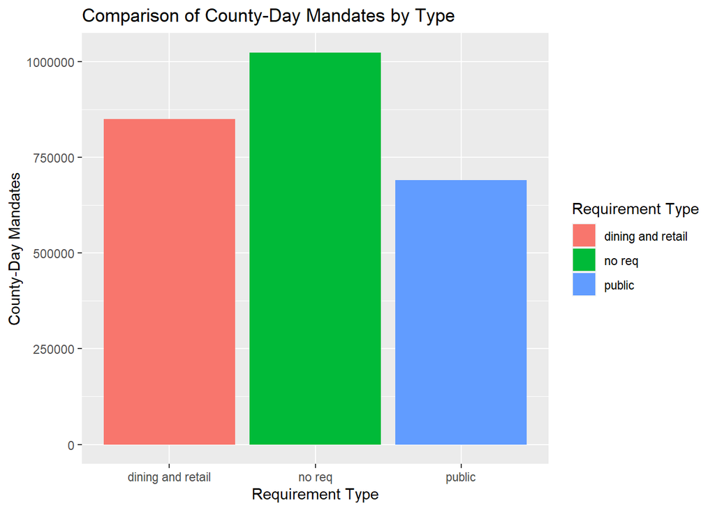

Please note that I’m not an epidemiologist, I’m just very used to working with data so I’m approaching it in a way that makes sense to me. (And if you are an epidemiologist- How did I do? Please leave a comment and/or suggestions to help me do this better!)